# Hospital Revenue Time Series Analysis Results

- Introduction
  - Research Question
  - Objectives & Goals
  - Initial Data State
- Model Selection
  - Stationarity
  - Seasonality
  - Autocorrelation
  - ARIMA Model
- Model Evaluation
  - Forecast
  - Measure
  - Identify
- Anotated Visualization
- Recomendations

## Introduction

### Research Question

How many days into the future is it possible to reliably forecast the hospital chain's revenue using time series modeling techniques?

### Objectives & Goals

**Goal 1:** Develop a reliable [Seasonal] Autoregressive Integrated Moving Average ([S]ARIMA) model using the hospital chain's daily revenue

- **Objective 1:** Determine whether the data contains any seasonality
- **Objective 2:** Determine whether the data contains any trends
- **Objective 3:** Determine whether the any autocorrelation exists within the dataset
- **Objective 4:** Train the [S]ARIMA model accounting for objectives 1-3

**Goal 2:** Determine the longest possible accurate forecast period for the model selected in Goal 1

- **Objective 1:** Create a 30-day forecast using the model from Goal 1
- **Objective 2:** Measure the accuracy of the forecasted values for each day
- **Objective 3:** Identify where the accuracy of the forecast drops below acceptable levels

### Initial Data State

The original dataset was formated with `Day` and `Revenue` columns, both numeric. To prepare the dataset for time series analysis a datetime index was created from the `Day` column resulting in a final index ranging from 1/1/2020 through 12/31/2021.

```python
import numpy as np
import pandas as pd
import os

%matplotlib inline

os.chdir('C:/users/user/source/repos/ms_data_analytics/advanced_data_analytics')
df = pd.read_csv('medical_time_series .csv', index_col='Day')
df.index = pd.to_datetime(df.index, unit='D', origin=pd.Timestamp('2019-12-31')).to_period('D')
df
```

| Day | Revenue |
| --- | --- |
| 2020-01-01 | 0.000000 |
| 2020-01-02 | -0.292356 |
| 2020-01-03 | -0.327772 |
| 2020-01-04 | -0.339987 |
| 2020-01-05 | -0.124888 |
| ... | ... |
| 2021-12-27 | 15.722056 |
| 2021-12-28 | 15.865822 |
| 2021-12-29 | 15.708988 |
| 2021-12-30 | 15.822867 |
| 2021-12-31 | 16.069429 |

731 rows × 1 columns

The realized daily revenue by day can be seen in the plot below. There appears to be an upward trend in the first year that stablizes by the third quarter. These qualities will be assessed further during the model selection phase.

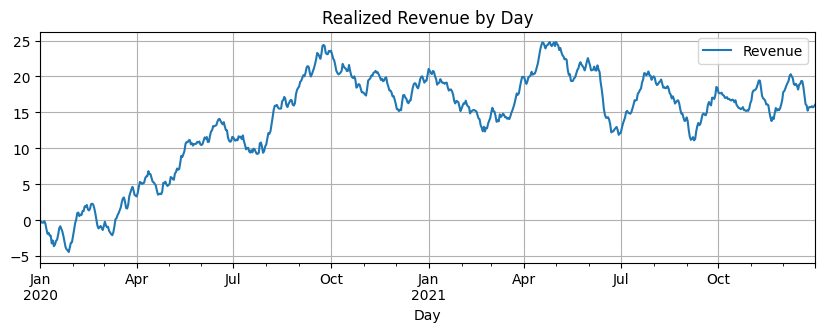

```python
df.plot(grid=True, figsize=(10, 3), title='Realized Revenue by Day')
```

## Model Selection

Several steps were taken to select the best [S]ARIMA model for the dataset.

### Stationarity

The *I* in SARIMA stands for *Integrated* and determines the number of differences needed to make the time series stationary. The Augmented Dickey Fuller (ADF) test was used to test the null hypothesis that the data is not stationary. A p-value less than .05 means the null hypothesis can be rejected. In this case it can't, meaning the data is not stationary.

```python
from statsmodels.tsa.stattools import adfuller

adf = adfuller(df, autolag='AIC')
adf_df = pd.Series(adf[:4], index=['Test Statistic', 'p-value', 'Lags', 'Observations'])
for k, v in adf[4].items():
    adf_df[f'Critical Value {k}'] = v
print('Augmented Dickey Fuller test:')
adf_df
```

```
Augmented Dickey Fuller test:
```

```
Test Statistic         -2.218319
p-value                 0.199664
Lags                    1.000000
Observations          729.000000
Critical Value 1%      -3.439352
Critical Value 5%      -2.865513
Critical Value 10%     -2.568886
dtype: float64
```

To coerce stationarity, the first difference was taken and the ADF test was reran. This time, the p-value is well below .05 meaning the null-hypothesis can be rejected and the data can be considered stationary.

```python
df_diff = df.diff().dropna()
adf = adfuller(df_diff, autolag='AIC')
adf_df = pd.Series(adf[:4], index=['Test Statistic', 'p-value', 'Lags', 'Observations'])
for k, v in adf[4].items():
    adf_df[f'Critical Value {k}'] = v
print('Augmented Dickey-Fuller test:')
adf_df
```

```
Augmented Dickey-Fuller test:
```

```
Test Statistic       -1.737477e+01
p-value               5.113207e-30
Lags                  0.000000e+00
Observations          7.290000e+02
Critical Value 1%    -3.439352e+00
Critical Value 5%    -2.865513e+00
Critical Value 10%   -2.568886e+00
dtype: float64
```

At this point, the data was split into training and testing sets for analysis. The last one month of data was reserved for the 30-day forecast required to answer the research question.

```python
df_train = df.loc[:'2021-11-30']
df_test = df.loc['2021-12-01':]
```

### Seasonality

Seasonality was assessed in a couple of different ways. First, the autocorrelation function was plotted over the detrended data. Detrending was performed by subtracting the rolling 180-day mean from each value. 180 days was selected because it is typical for hospital revenue to cycle at 90 days. Using double the expected season allows differences across potential seasons to be minimized. If any seasonality existed, there would be periodic spikes in the plot. Since there are not, the data is non-seasonal.

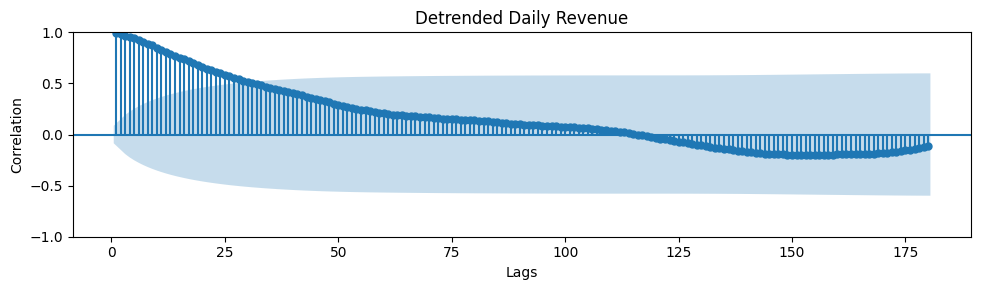

```python
from statsmodels.graphics.tsaplots import plot_acf
import matplotlib.pyplot as plt

detrend = df_train - df_train.rolling(180).mean()
detrend.dropna(inplace=True)

_, ax = plt.subplots(figsize=(10, 3))
plot_acf(detrend, lags=180, zero=False, title='Detrended Daily Revenue', ax=ax)
ax.set_xlabel('Lags')
ax.set_ylabel('Correlation')
plt.tight_layout()
print()
```

The `auto_arima` function was also used to confirm the lack of seasonality in the dataset. This function iteratively tests the hyperparameters to find the best model fit, including seasonal models, if applicable. The final model identified was ARIMA(1,1,0) with no seasonal components.

```python
# %pip install pmdarima
from pmdarima import auto_arima

stepwise_fit = auto_arima(df_train.Revenue, trace=True, suppress_warnings=True)
```

```
Performing stepwise search to minimize aic
 ARIMA(2,1,2)(0,0,0)[0] intercept   : AIC=842.924, Time=2.85 sec
 ARIMA(0,1,0)(0,0,0)[0] intercept   : AIC=967.060, Time=0.69 sec
 ARIMA(1,1,0)(0,0,0)[0] intercept   : AIC=840.982, Time=0.58 sec
 ARIMA(0,1,1)(0,0,0)[0] intercept   : AIC=863.135, Time=0.67 sec
 ARIMA(0,1,0)(0,0,0)[0]             : AIC=966.774, Time=0.24 sec
 ARIMA(2,1,0)(0,0,0)[0] intercept   : AIC=842.980, Time=0.84 sec
 ARIMA(1,1,1)(0,0,0)[0] intercept   : AIC=842.981, Time=0.72 sec
 ARIMA(2,1,1)(0,0,0)[0] intercept   : AIC=842.946, Time=2.96 sec
 ARIMA(1,1,0)(0,0,0)[0]             : AIC=839.719, Time=0.24 sec
 ARIMA(2,1,0)(0,0,0)[0]             : AIC=841.713, Time=0.54 sec
 ARIMA(1,1,1)(0,0,0)[0]             : AIC=841.715, Time=0.50 sec
 ARIMA(0,1,1)(0,0,0)[0]             : AIC=862.247, Time=0.25 sec
 ARIMA(2,1,1)(0,0,0)[0]             : AIC=841.656, Time=1.20 sec

Best model:  ARIMA(1,1,0)(0,0,0)[0]
Total fit time: 12.327 seconds
```

### Autocorrelation

In the previous section, the order of the ARIMA model identified was (1,1,0). This indicates that an AR(1) model should be used after taking the first difference of the time series. To confirm these findings, the autocorrelation and partial autocorrelation functions were plotted. In the partial autocorrelation plot, only the first lag is correlated. This implies that the reason for any correlation in the second lag of the autocorrelation plot is only a result of it including correlation from the first lag. This confirms the `auto_arima` findings that an AR(1) model is best suited to the time series.

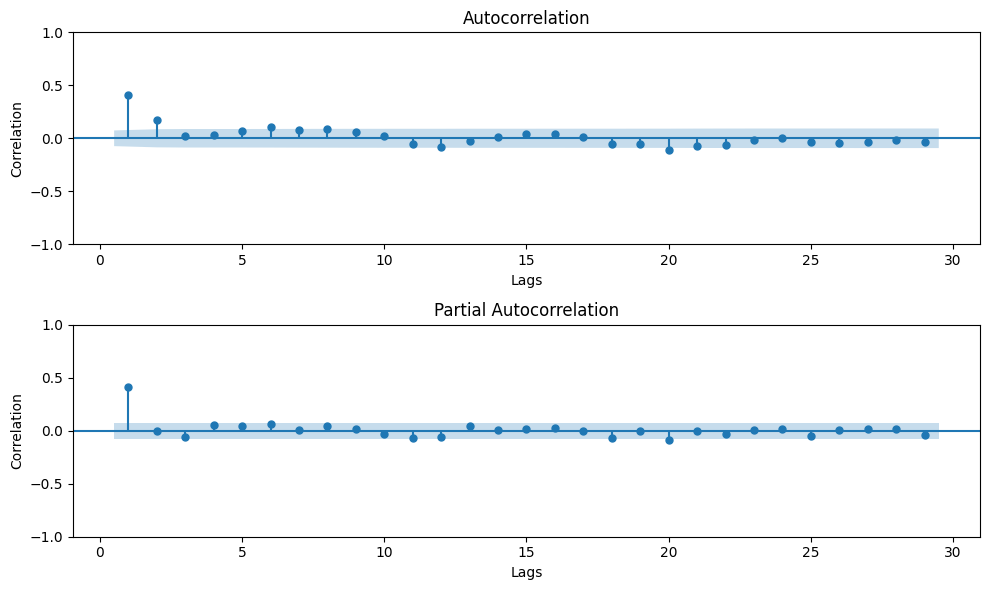

```python
from statsmodels.graphics.tsaplots import plot_pacf

df_train_diff = df_train.diff().dropna()
_, (ax1, ax2) = plt.subplots(2, figsize=(10, 6))
plot_acf(df_train_diff, zero=False, ax=ax1)
plot_pacf(df_train_diff, zero=False, method='ywm', ax=ax2)
ax1.set_xlabel('Lags')
ax1.set_ylabel('Correlation')
ax2.set_xlabel('Lags')
ax2.set_ylabel('Correlation')
plt.tight_layout()
print()
```

### ARIMA Model

```python
from statsmodels.tsa.arima.model import ARIMA

mod = ARIMA(df_train, order=(1, 1, 0))
res = mod.fit()
res.summary()
```

SARIMAX Results

| Dep. Variable: | Revenue | No. Observations: | 700 |
| --- | --- | --- | --- |
| Model: | ARIMA(1, 1, 0) | Log Likelihood | -417.859 |
| Date: | Mon, 26 Dec 2022 | AIC | 839.719 |
| Time: | 21:16:44 | BIC | 848.818 |
| Sample: | 01-01-2020 | HQIC | 843.236 |
|  | - 11-30-2021 |  |  |
| Covariance Type: | opg |  |  |

|  | coef | std err | z | P>\|z\| | [0.025 | 0.975] |
| --- | --- | --- | --- | --- | --- | --- |
| ar.L1 | 0.4109 | 0.035 | 11.757 | 0.000 | 0.342 | 0.479 |
| sigma2 | 0.1935 | 0.011 | 17.553 | 0.000 | 0.172 | 0.215 |

| Ljung-Box (L1) (Q): | 0.00 | Jarque-Bera (JB): | 1.60 |
| --- | --- | --- | --- |
| Prob(Q): | 0.96 | Prob(JB): | 0.45 |
| Heteroskedasticity (H): | 0.97 | Skew: | -0.02 |
| Prob(H) (two-sided): | 0.83 | Kurtosis: | 2.77 |

Warnings:  
[1] Covariance matrix calculated using the outer product of gradients (complex-step).

## Model Evaluation

The model was evaluated using the Mean Absolute Error (MAE) and the `plot_diagnostics` method of the model. The formula for MAE is:

$$MAE = {1 \over n}{\sum_{i=1}^{n}|x_i-x|}$$

The MAE for the predictions made on the training data was $0.35 million. Reviewing the diagnostic plots, it can be seen that the residuals are normally distributed and are not autocorrelated.

```
Mean Absolute Error: 0.35442734811957094
```

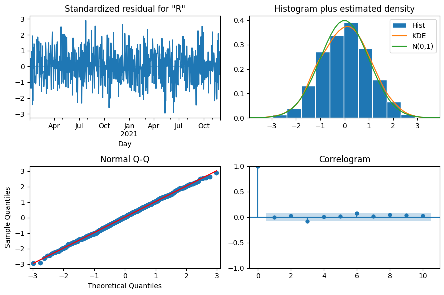

```python
mae = np.mean(np.abs(res.resid))
print('Mean Absolute Error:', mae, '\n')
res.plot_diagnostics(figsize=(9, 6))
plt.tight_layout()
```

### Forecast

The 30-day forecast was generated for comparison with the testing data.

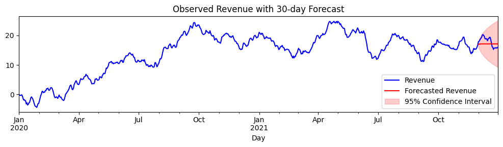

```python
forecast = res.get_forecast(30)
ci = forecast.conf_int()
predicted_mean = forecast.predicted_mean

_, ax = plt.subplots(figsize=(10, 3))
df.plot(ax=ax, color='b')
predicted_mean.plot(ax=ax, color='r', label='Forecasted Revenue')
ax.fill_between(ci.index, ci['lower Revenue'], ci['upper Revenue'],
                 color='r', alpha=0.2, label='95% Confidence Interval')
ax.set_title('Observed Revenue with 30-day Forecast')
plt.legend()
plt.tight_layout()
```

### Measure

To evaluate the forecast quality at 1- to 30-day intervals, the cumualtive MAE was calculated. For interpretability, the proportion MAE of Revenue at the end of each period was also calculated.

| Day | Revenue | predicted_mean | resid | cum_mae | cum_mae_pct_Revenue |
| --- | --- | --- | --- | --- | --- |
| 2021-12-01 | 17.837440 | 16.953303 | -0.884137 | 0.884137 | 0.049566 |
| 2021-12-02 | 17.970498 | 17.060282 | -0.910216 | 0.897176 | 0.049925 |
| 2021-12-03 | 18.343148 | 17.104239 | -1.238909 | 1.011087 | 0.055121 |
| 2021-12-04 | 18.760310 | 17.122301 | -1.638009 | 1.167818 | 0.062249 |
| 2021-12-05 | 19.080317 | 17.129722 | -1.950595 | 1.324373 | 0.069410 |
| 2021-12-06 | 19.378591 | 17.132772 | -2.245819 | 1.477948 | 0.076267 |
| 2021-12-07 | 20.076182 | 17.134024 | -2.942157 | 1.687120 | 0.084036 |
| 2021-12-08 | 20.307137 | 17.134539 | -3.172597 | 1.872805 | 0.092224 |
| 2021-12-09 | 20.035505 | 17.134751 | -2.900754 | 1.987022 | 0.099175 |
| 2021-12-10 | 19.750009 | 17.134838 | -2.615171 | 2.049836 | 0.103789 |
| 2021-12-11 | 18.925067 | 17.134874 | -1.790193 | 2.026233 | 0.107066 |
| 2021-12-12 | 18.803687 | 17.134888 | -1.668799 | 1.996446 | 0.106173 |
| 2021-12-13 | 18.978486 | 17.134894 | -1.843592 | 1.984688 | 0.104576 |
| 2021-12-14 | 18.694026 | 17.134897 | -1.559129 | 1.954291 | 0.104541 |
| 2021-12-15 | 18.184189 | 17.134898 | -1.049291 | 1.893958 | 0.104154 |
| 2021-12-16 | 18.875765 | 17.134898 | -1.740867 | 1.884390 | 0.099831 |
| 2021-12-17 | 18.968519 | 17.134898 | -1.833621 | 1.881403 | 0.099186 |
| 2021-12-18 | 19.372149 | 17.134898 | -2.237251 | 1.901173 | 0.098139 |
| 2021-12-19 | 19.338288 | 17.134898 | -2.203390 | 1.917079 | 0.099134 |
| 2021-12-20 | 18.512654 | 17.134898 | -1.377755 | 1.890113 | 0.102098 |
| 2021-12-21 | 17.333768 | 17.134898 | -0.198869 | 1.809577 | 0.104396 |
| 2021-12-22 | 16.155111 | 17.134898 | 0.979788 | 1.771860 | 0.109678 |
| 2021-12-23 | 15.981459 | 17.134898 | 1.153440 | 1.744972 | 0.109187 |
| 2021-12-24 | 15.246219 | 17.134898 | 1.888679 | 1.750960 | 0.114845 |
| 2021-12-25 | 15.693218 | 17.134898 | 1.441680 | 1.738588 | 0.110786 |
| 2021-12-26 | 15.754749 | 17.134898 | 1.380150 | 1.724802 | 0.109478 |
| 2021-12-27 | 15.722056 | 17.134898 | 1.412843 | 1.713248 | 0.108971 |
| 2021-12-28 | 15.865822 | 17.134898 | 1.269077 | 1.697385 | 0.106984 |
| 2021-12-29 | 15.708988 | 17.134898 | 1.425911 | 1.688024 | 0.107456 |
| 2021-12-30 | 15.822867 | 17.134898 | 1.312031 | 1.675491 | 0.105890 |
| 2021-12-31 | 16.069429 | NaN | NaN | NaN | NaN |

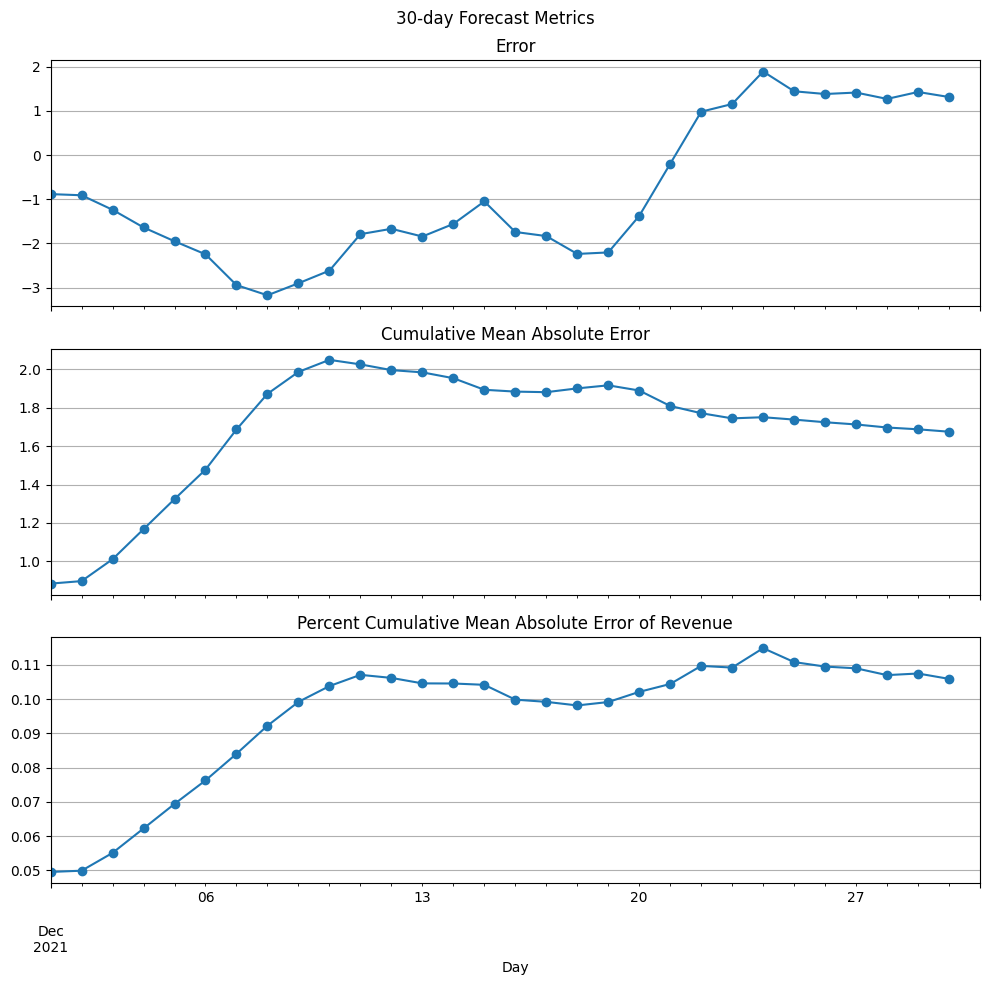

```python
metric_df = df_test.join(forecast.predicted_mean)
metric_df['resid'] = metric_df.predicted_mean.sub(metric_df.Revenue)
metric_df['cum_mae'] = metric_df.resid.abs().cumsum().div(metric_df.index.day)
metric_df['cum_mae_pct_Revenue'] = metric_df.cum_mae.div(metric_df.Revenue)

fig, (ax1, ax2, ax3) = plt.subplots(3, sharex=True, figsize=(10, 10))
fig.suptitle('30-day Forecast Metrics')
metric_df.resid.plot(ax=ax1, grid=True, marker='o', title='Error')
metric_df.cum_mae.plot(ax=ax2, grid=True, marker='o',
                       title='Cumulative Mean Absolute Error')
metric_df.cum_mae_pct_Revenue.plot(ax=ax3, grid=True, marker='o',
                                   title='Percent Cumulative Mean '
                                         'Absolute Error of Revenue')
plt.tight_layout()

metric_df
```

### Identify

From the information above, a few conclusions can be drawn. First, the predicted mean of the forecasted values flatlines beginning on December 15th, 2021, or at two weeks. This behavior is expected because of the nature of a time series model that only accounts for a single lag. These models must use predicted values to predict further than one step into the future. This means the predictions become less valuable the farther into the future they are. For this reason, the model should not be used to forecast farther than two weeks into the future.

Depending on the operating margins of the hospital chain, a more conservative forecast period should be used. In the 1- and 2-day forecasts, the margin of error is below 5%. To be safe, no longer than a 7-day period should be forecasted using the model with the currently collected data.

## Annotated Visualization

The 30-day forecast compared to the testing data is displayed in the plot below along with the 95% confidence interval. Notice that the observed Revenue is consistently within the bounds of the confidence interval.

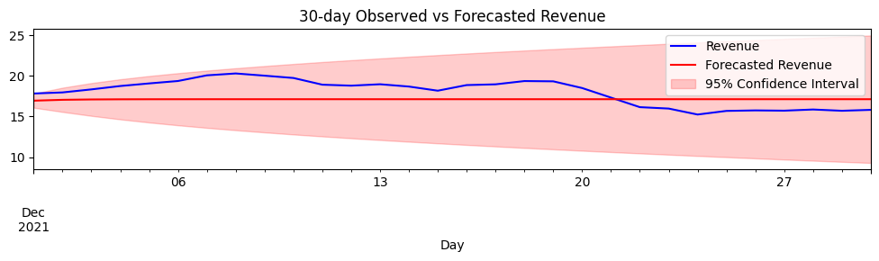

```python
_, ax = plt.subplots(figsize=(10, 3))
df_test[:'2021-12-30'].plot(ax=ax, color='b')
predicted_mean.plot(ax=ax, color='r', label='Forecasted Revenue')
ax.fill_between(ci.index, ci['lower Revenue'], ci['upper Revenue'],
                 color='r', alpha=0.2, label='95% Confidence Interval')
ax.set_title('30-day Observed vs Forecasted Revenue')
plt.legend()
plt.tight_layout()
```

## Recommendations

The model should be used in an exploratory fashion to continue model evaluation for 7-day forecasts. Though, without model updates, it is likely that the model will not maintain any level of accuracy for long in the beginning. This leads to the second recommendation, which is to collect more data with which the model can be updated. This is needed for two reasons. First, time series models are more accurate when supplied with recent data. Second, the first year of data is reflective of the organization’s state as a startup. The trends appear to normalize in the second year. With continued evaluation, seasons may become visible, allowing the model to forecast more accurately, and farther into the future. The last recommendation is to automate the process of staging the most recent data and updating the model. By automating this step, the model will always have access to the most recent data, allowing data science efforts to focus on tuning the model for the best performance rather than obtaining more training data.